# SpotifyTopUtwory2010-2019

Filip Szkamruk

2026-01-19

## Pakiety których będę używał

```r
library(dplyr)
```

```r
library(ggplot2)
library(psych)
library(mice)
library(knitr)
library(tidyr)
```

# Wprowadzenie

W poniższym projekcie poddam analizie zestaw danych pochodzący z platformy streamingowej Spotify, obejmujący najpopularniejsze utwory z lat 2010-2019. Spotify, jako lider rynku muzyki cyfrowej, co roku publikuje rankingi najchętniej słuchanych utworów, które stanowią doskonałe odzwierciedlenie globalnych trendów kulturowych i muzycznych. To, co czyni ten zbiór danych wyjątkowym, to nie tylko obecność nazwisk artystów i tytułów hitów, ale przede wszystkim zaawansowane dane na temat audio. Każdy utwór w bazie jest opisywany przez zestaw parametrów technicznych.

## Zmienne

- **Title** - Tytuł utworu (tekst)
- **Artist** - Artysta lub zespół (tekst)
- **Top Genre** - Główny gatunek muzyczny utworu (tekst)
- **Year** - Rok wydania utworu (liczbowo od 2010 do 2019)
- **BPM** - Szybkość utworu przedstawiona w liczbie uderzeń przypadających na jedną minute (liczbowo, liczby całkowite u nas od 43 do 206)
- **NRGY** - Energia utworu, jego intensywność oraz dynamika. Jest ona oceniana na podstawie:
  - Zakresu dynamicznego czyli najcichszym, a najgłośniejszym fragmentem, stały głośny fragment podnosi wynik energii
  - Odczuwalnej głośności, np. wysokie, piskliwe dźwięki podnoszą wynik
  - Barwy dźwięku, czysta barwa np. fortepianu obniży wynik energii natomiast mocna gitara elektryczna ją podniesie
  - Częstotliwości z jaką pojawiają się nowe dźwięki, np. szybkie uderzenia perkusji podniosą wynik
  - Entropii czyli stopień złożoności i przewidywalności dźwięku. (zakres od 0 utwór najmniej energiczny do 100 najbardziej)
- **DNCE** - Taneczność, jak bardzo utwór pasuje do tańczenia oceniane przez kombinacje:
  - Tempa, nie może być ani za szybko ani za wolno
  - Stabilności rytmu, stały rytm sprzyja taneczności
  - Silę bitu, im bardziej wyraźny, dobrze słyszalny bit tym większy wynik
  - Ogólnej regularności czyli czy rytm jest przewidywalny, czy nie ma nagłych pauz lub innych zmian (zakres od 0 utwór najmniej taneczny do 100 najbardziej)
- **DB** - Decybele czyli miara głośności utworu (0 to maksymalna wartość głośności, dlatego nasze dane będą głównie ujemne)
- **VAL** - Wskaźnik pozytywności utworu (zakres od 0 utwór brzmiące na negatywny, smutny, depresyjny, agresywny, do 100 utwór szczęśliwy, pozytywny, euforyczny)
- **DUR** - Czas trwania (liczbowo w sekundach)
- **ACOUS** - Akustyczność, czyli jak bardzo utwór składa się z brzmień instrumentów akustycznych a nie przetworzonych lub wzmacnianych elektrycznie, akustyczne instrumenty to te które wytwarzają dźwięk przy użyciu drgań (zakres od 0 utwór najmniej akustyczny do 100 najbardziej)
- **SPCH** - Stopień jak bardzo utwór jest wyrażony w słowach:
  - < 33 Najprawdopodobniej instrumentale albo utwory popowe, ponieważ algorytm traktuje śpiew bardziej jako instrument niż jako mowę
  - 33-66 Utwory z muzyką oraz tekstem ułożone sekcjami lub w tym samym czasie, zazwyczaj do tej sekcji trafiają utwory rapowe
  - > 66 Utwory najprawdopodobniej składające się całkowicie tylko ze słów (zakres od 0 do 100, wartości powyżej 66 opisują utwory najprawdopodobniej składające się całkowicie tylko ze słów, pomiędzy 33 i 66 utwory z muzyką oraz tekstem ułożone sekcjami lub w tym samym czasie, zazwyczaj do tej sekcji trafiają utwory rapowe, a poniżej 33 najprawdopodobniej instrumentale albo utwory popowe, ponieważ algorytm traktuje śpiew bardziej jako instrument niż jako mowę)

# Przegląd danych

```r
spotify <- read.csv("C:\\Users\\admin\\Desktop\\ProjektBazaSpotify\\SPOTIFYLISTA.csv")

spotify<- spotify %>%
  select(-c(index,live,pop))

head(spotify,9)
```

```
##                                        title        artist       top.genre year
## 1                           Hey, Soul Sister         Train      neo mellow 2010
## 2                       Love The Way You Lie        Eminem detroit hip hop 2010
## 3                                    TiK ToK         Kesha       dance pop 2010
## 4                                Bad Romance     Lady Gaga       dance pop 2010
## 5                       Just the Way You Are    Bruno Mars             pop 2010
## 6                                       Baby Justin Bieber    canadian pop 2010
## 7                                   Dynamite     Taio Cruz       dance pop 2010
## 8                                    Secrets   OneRepublic       dance pop 2010
## 9 Empire State of Mind (Part II) Broken Down   Alicia Keys         hip pop 2010
##   bpm nrgy dnce dB val dur acous spch
## 1  97   89   67 -4  80 217    19    4
## 2  87   93   75 -5  64 263    24   23
## 3 120   84   76 -3  71 200    10   14
## 4 119   92   70 -4  71 295     0    4
## 5 109   84   64 -5  43 221     2    4
## 6  65   86   73 -5  54 214     4   14
## 7 120   78   75 -4  82 203     0    9
## 8 148   76   52 -6  38 225     7    4
## 9  93   37   48 -8  14 216    74    3
```

```r
tail(spotify,9)
```

```
##                                                           title
## 595                                   No Guidance (feat. Drake)
## 596                              Antisocial (with Travis Scott)
## 597             Taki Taki (feat. Selena Gomez, Ozuna & Cardi B)
## 598                                           Con Calma - Remix
## 599                         Find U Again (feat. Camila Cabello)
## 600               Cross Me (feat. Chance the Rapper & PnB Rock)
## 601 No Brainer (feat. Justin Bieber, Chance the Rapper & Quavo)
## 602             Nothing Breaks Like a Heart (feat. Miley Cyrus)
## 603                                            Kills You Slowly
##               artist       top.genre year bpm nrgy dnce dB val dur acous spch
## 595      Chris Brown       dance pop 2019  93   45   70 -7  14 261    12   15
## 596       Ed Sheeran             pop 2019 152   82   72 -5  91 162    13    5
## 597         DJ Snake electronic trap 2019  96   80   84 -4  62 213    16   23
## 598     Daddy Yankee           latin 2019  94   87   74 -3  61 181    17    5
## 599      Mark Ronson       dance pop 2019 104   66   61 -7  16 176     1    3
## 600       Ed Sheeran             pop 2019  95   79   75 -6  61 206    21   12
## 601        DJ Khaled       dance pop 2019 136   76   53 -5  65 260     7   34
## 602      Mark Ronson       dance pop 2019 114   79   60 -6  24 217     1    7
## 603 The Chainsmokers      electropop 2019 150   44   70 -9  23 213     6    6
```

```r
str(spotify)
```

```
## 'data.frame':    603 obs. of  12 variables:
##  $ title    : chr  "Hey, Soul Sister" "Love The Way You Lie" "TiK ToK" "Bad Romance" ...
##  $ artist   : chr  "Train" "Eminem" "Kesha" "Lady Gaga" ...
##  $ top.genre: chr  "neo mellow" "detroit hip hop" "dance pop" "dance pop" ...
##  $ year     : int  2010 2010 2010 2010 2010 2010 2010 2010 2010 2010 ...
##  $ bpm      : int  97 87 120 119 109 65 120 148 93 126 ...
##  $ nrgy     : int  89 93 84 92 84 86 78 76 37 72 ...
##  $ dnce     : int  67 75 76 70 64 73 75 52 48 79 ...
##  $ dB       : int  -4 -5 -3 -4 -5 -5 -4 -6 -8 -4 ...
##  $ val      : int  80 64 71 71 43 54 82 38 14 61 ...
##  $ dur      : int  217 263 200 295 221 214 203 225 216 235 ...
##  $ acous    : int  19 24 10 0 2 4 0 7 74 13 ...
##  $ spch     : int  4 23 14 4 4 14 9 4 3 4 ...
```

Z naszego zbioru danych pozbyliśmy się kolumny z ID, nie potrzebujemy jej, LIVE, ponieważ wskaźnik praktycznie ciągle się myli, system nie odróżnia chórków od szumu publiczności oraz POP, ponieważ sposób ich kategoryzacji w bazie był niejasny oraz dane były przestarzałe np. często piosenki z top listy miały popularność równą 0.

```r
table(spotify$top.genre)
```

```
##
##              acoustic pop              alaska indie           alternative r&b
##                         2                         1                         1
##                   art pop               atl hip hop          australian dance
##                         8                         5                         6
##        australian hip hop            australian pop             barbadian pop
##                         1                         5                        15
##               baroque pop               belgian edm                  big room
##                         2                         2                        10
##                  boy band              british soul                   brostep
##                        15                        11                         2
## canadian contemporary r&b          canadian hip hop            canadian latin
##                         9                         2                         1
##              canadian pop                 candy pop               celtic rock
##                        34                         2                         1
##               chicago rap             colombian pop                complextro
##                         1                         3                         6
##      contemporary country                 dance pop                danish pop
##                         1                       327                         1
##           detroit hip hop                 downtempo                       edm
##                         2                         2                         5
##                   electro             electro house           electronic trap
##                         2                         1                         2
##                electropop               escape room                  folk-pop
##                        13                         2                         2
##          french indie pop                   hip hop                   hip pop
##                         1                         4                         6
##                 hollywood                     house                 indie pop
##                         1                         1                         2
##   irish singer-songwriter                     latin              metropopolis
##                         1                         4                         1
##              moroccan pop                neo mellow            permanent wave
##                         1                         9                         4
##                       pop            tropical house
##                        60                         3
```

```r
spotify$top.genre <- as.factor(spotify$top.genre)

spotify %>%
  select(year, bpm, nrgy,dnce,dB,val,dur,acous,spch) %>%
  describe()
```

```
##       vars   n    mean    sd median trimmed   mad  min  max range   skew
## year     1 603 2014.59  2.61   2015 2014.66  2.97 2010 2019     9  -0.19
## bpm      2 603  118.55 24.80    120  116.86 22.24    0  206   206   0.53
## nrgy     3 603   70.50 16.31     74   72.13 14.83    0   98    98  -0.98
## dnce     4 603   64.38 13.38     66   65.22 11.86    0   97    97  -0.68
## dB       5 603   -5.58  2.80     -5   -5.37  1.48  -60   -2    58 -12.39
## val      6 603   52.23 22.51     52   52.46 25.20    0   98    98  -0.07
## dur      7 603  224.67 34.13    221  221.69 28.17  134  424   290   1.33
## acous    8 603   14.33 20.77      6    9.46  7.41    0   99    99   2.19
## spch     9 603    8.36  7.48      5    6.67  2.97    0   48    48   2.53
##       kurtosis   se
## year     -0.98 0.11
## bpm       1.67 1.01
## nrgy      1.02 0.66
## dnce      1.03 0.54
## dB      235.04 0.11
## val      -0.83 0.92
## dur       4.11 1.39
## acous     4.40 0.85
## spch      6.99 0.30
```

```r
spotify %>%
  filter(bpm==0)
```

```
##               title artist    top.genre year bpm nrgy dnce  dB val dur acous
## 1 Million Years Ago  Adele british soul 2016   0    0    0 -60   0 227     0
##   spch
## 1    0
```

```r
spotify <- spotify %>%
  filter(bpm > 0)

spotify %>%
  select(year, bpm, nrgy,dnce,dB,val,dur,acous,spch) %>%
  describe()
```

```
##       vars   n    mean    sd median trimmed   mad  min  max range  skew
## year     1 602 2014.59  2.61 2015.0 2014.65  2.97 2010 2019     9 -0.18
## bpm      2 602  118.74 24.34  120.0  116.92 22.24   43  206   163  0.73
## nrgy     3 602   70.62 16.07   74.0   72.18 14.83    4   98    94 -0.91
## dnce     4 602   64.49 13.13   66.0   65.25 11.86   23   97    74 -0.55
## dB       5 602   -5.49  1.70   -5.0   -5.37  1.48  -15   -2    13 -0.98
## val      6 602   52.31 22.43   52.0   52.52 25.20    4   98    94 -0.07
## dur      7 602  224.67 34.16  220.5  221.68 27.43  134  424   290  1.33
## acous    8 602   14.35 20.78    6.0    9.48  7.41    0   99    99  2.19
## spch     9 602    8.37  7.48    5.0    6.68  2.97    3   48    45  2.53
##       kurtosis   se
## year     -0.98 0.11
## bpm       1.08 0.99
## nrgy      0.68 0.65
## dnce      0.41 0.54
## dB        2.33 0.07
## val      -0.84 0.91
## dur       4.10 1.39
## acous     4.39 0.85
## spch      7.00 0.30
```

```r
spotify %>%
  filter(acous==0)
```

```
##                                                           title
## 1                                                   Bad Romance
## 2                                                      Dynamite
## 3                                                     Alejandro
## 4                                               Meet Me Halfway
## 5                                                   Take It Off
## 6                                                        Misery
## 7                                                        Animal
## 8                                              California Gurls
## 9                                            Not Myself Tonight
## 10                                             Break Your Heart
## 11                                        Run the World (Girls)
## 12                                                What the Hell
## 13                                                Born This Way
## 14                                                      Monster
```

[output cut: 204 more lines]

Trzeba był usunąć utwory, które były ewidentnie wadliwe, ponieważ miały BPM równe 0 co jest niemożliwe, chyba, że byłoby to nagranie np szumu deszczu, ale wtedy nie było by w naszych danych top utworów. Inne wartości z min 0 mogą istnieć, bo np. utwór z ACOUS == 0 wskazuje na utwór czysto elektroniczny.

```
##  /\     /\
## {  `---'  }
## {  O   O  }
## ==>  V <==  No need for mice. This data set is completely observed.
##  \  \|/  /
##   `-----'
```

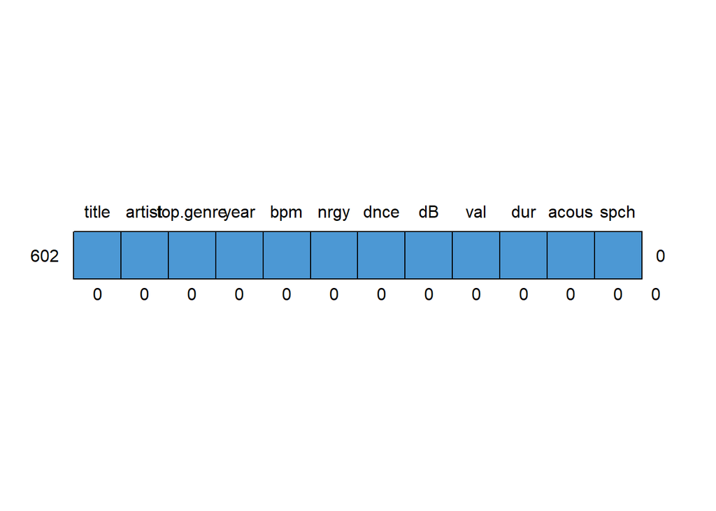

```
##     title artist top.genre year bpm nrgy dnce dB val dur acous spch
## 602     1      1         1    1   1    1    1  1   1   1     1    1 0
##         0      0         0    0   0    0    0  0   0   0     0    0 0
```

```r
md.pattern(spotify)
```

Nie ma wartości brakujących więc możemy przechodzić do analizowania bazy danych.

# Analiza danych

Zacznę od sprawdzenia czy w przeciągu 9 lat jakiś artysta pojawia się więcej niż raz czy może jest to jednak coś nietypowego.

```r
spotify %>%
  count(artist, sort = TRUE)
```

```
##                       artist  n
## 1                 Katy Perry 17
## 2              Justin Bieber 16
## 3                   Maroon 5 15
## 4                    Rihanna 15
## 5                  Lady Gaga 14
## 6                 Bruno Mars 13
## 7                 Ed Sheeran 11
## 8                    Pitbull 11
## 9               Shawn Mendes 11
## 10          The Chainsmokers 11
## 11             Calvin Harris 10
## 12            Jennifer Lopez 10
## 13                     Adele  9
## 14             Ariana Grande  9
```

[output cut: 170 more lines]

Widać że artyści pojawiający się więcej niż 2 razy stanowią mniej niż połowę wszystkich artystów, a top 10 artystów pojawia się znacząco więcej razy niż reszta, nie są to w takim razie tak zwani “One-hit Wonder” artyści którzy są znani z jednej popularnej piosenki. Zobaczmy teraz czy dominowali oni rankingi w konkretnych latach czy może regularnie wydawali hity na przeciągu lat.

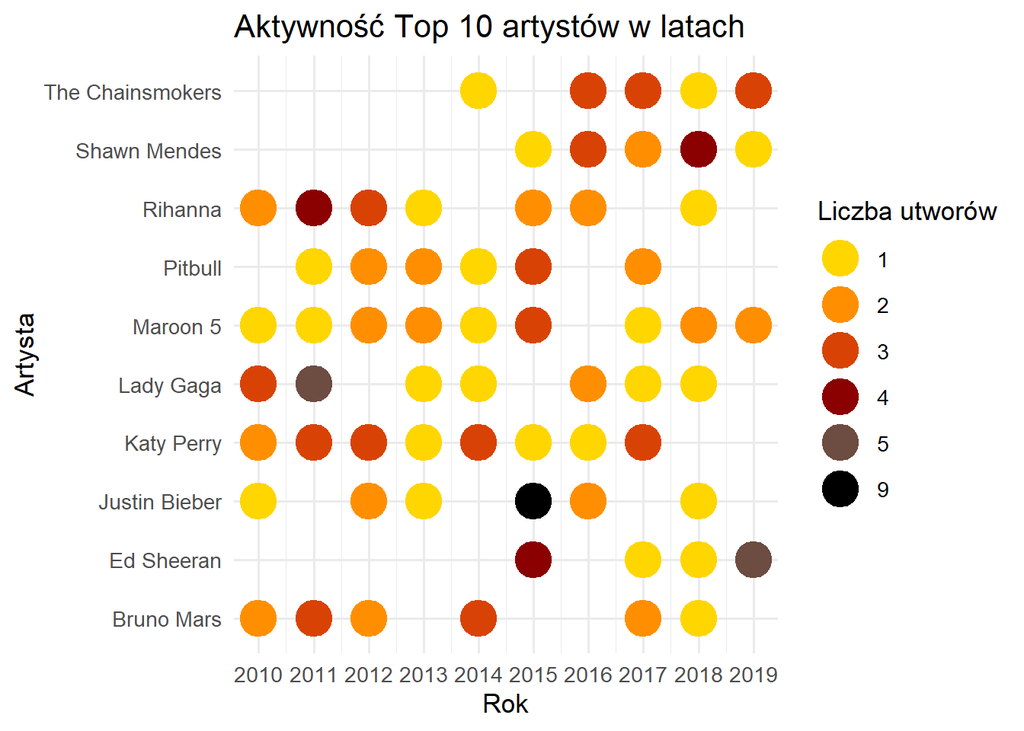

```r
top10<- spotify %>%
  count(artist, sort = TRUE) %>%
  head(10) %>%
  pull(artist)

spotify %>%
  filter(artist %in% top10) %>%
  count(artist, year) %>%
  ggplot(aes(x = year, y = artist, col = as.factor(n))) +
  geom_point(size = 8) +
  scale_x_continuous(breaks = 2010:2019) +
  scale_color_manual(values = c(
    "1" = "#FFD600",
    "2" = "#FF8F00",
    "3" = "#D84305",
    "4" = "darkred",
    "5" = "#6D4C41",
    "9" = "#000000"
  )) +
  labs(title = "Aktywność Top 10 artystów w latach",
       x = "Rok",
       y = "Artysta",
       color = "Liczba utworów") +
  theme_minimal(base_size = 13)
```

Z wykresu w oczy od razu rzuca się, że w roku 2015 Justin Bieber miał aż 9 różnych piosenek będących w topce roku, jest to zaskakujący wynik patrząc na to, że w poprzednich latach nie odnosił aż takich sukcesów oraz jest to jedyna tak duża wartość na wykresie. Przebadam teraz jaka jest zależność pomiędzy utworami artysty, a resztą utorów z 2015, sprawdzimy czy Bieber wbił się idealnie w trendy czy może jednak pod pasował je sobie.

```r
bieber_2015 <- spotify %>%
  filter(artist == "Justin Bieber", year == 2015)
bieber_2015
```

```
##                          title        artist    top.genre year bpm nrgy dnce
## 1                Love Yourself Justin Bieber canadian pop 2015 100   38   61
## 2                        Sorry Justin Bieber canadian pop 2015 100   76   65
## 3            What Do You Mean? Justin Bieber canadian pop 2015 125   57   85
## 4                      Company Justin Bieber canadian pop 2015  95   80   59
## 5                I'll Show You Justin Bieber canadian pop 2015 192   61   36
## 6                  The Feeling Justin Bieber canadian pop 2015 127   81   53
## 7 What Do You Mean? - Acoustic Justin Bieber canadian pop 2015 125   36   77
## 8                Mark My Words Justin Bieber canadian pop 2015 114   26   38
## 9                     Been You Justin Bieber canadian pop 2015 113   78   74
##    dB val dur acous spch
## 1 -10  52 234    84   44
## 2  -4  41 201     8    5
## 3  -8  79 206    59   10
## 4  -5  43 208    13    6
## 5  -7   8 200     5   10
## 6  -6  21 245     8    6
## 7 -11  76 204    79    4
## 8  -9  52 134    88    3
## 9  -6  86 199     2    7
```

```r
dane_2015 <- spotify %>%
  filter(year == 2015) %>%
  mutate(kategoria = ifelse(artist == "Justin Bieber", "Bieber", "Reszta 2015"))

dane_2015 %>%
  group_by(kategoria) %>%
  summarise(srednie_bpm = mean(bpm), srednia_nrgy = mean(nrgy), srednia_dnce = mean(dnce), srednia_dB = mean(dB), srednie_val = mean(val), srednia_dur = mean(dur), srednia_acous = mean(acous), srednia_spch= mean(spch))
```

```
## # A tibble: 2 × 9
##   kategoria   srednie_bpm srednia_nrgy srednia_dnce srednia_dB srednie_val
##   <chr>             <dbl>        <dbl>        <dbl>      <dbl>       <dbl>
## 1 Bieber             121.         59.2         60.9      -7.33        50.9
## 2 Reszta 2015        120.         71.5         64.0      -5.44        52.7
## # ℹ 3 more variables: srednia_dur <dbl>, srednia_acous <dbl>,
## #   srednia_spch <dbl>
```

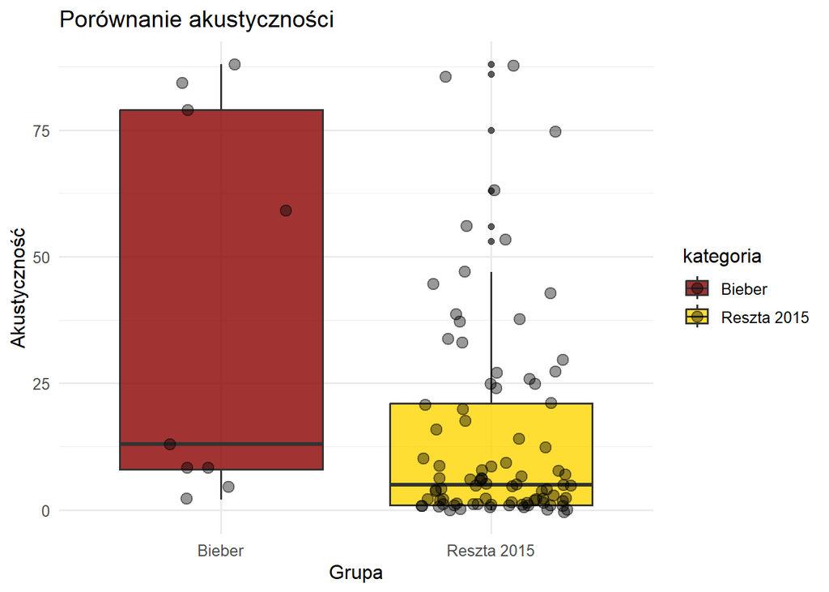

```r
  dane_2015 %>%
  ggplot(aes(x = kategoria, y = acous, fill = kategoria)) +
  geom_boxplot(alpha = 0.8) +
  geom_jitter(width = 0.3, size = 3, alpha = 0.4) +
  scale_fill_manual(values = c("Bieber" = "darkred", "Reszta 2015" = "#FFD600")) +
  theme_minimal(12) +
  labs(title = "Porównanie akustyczności", x = "Grupa", y = "Akustyczność")
```

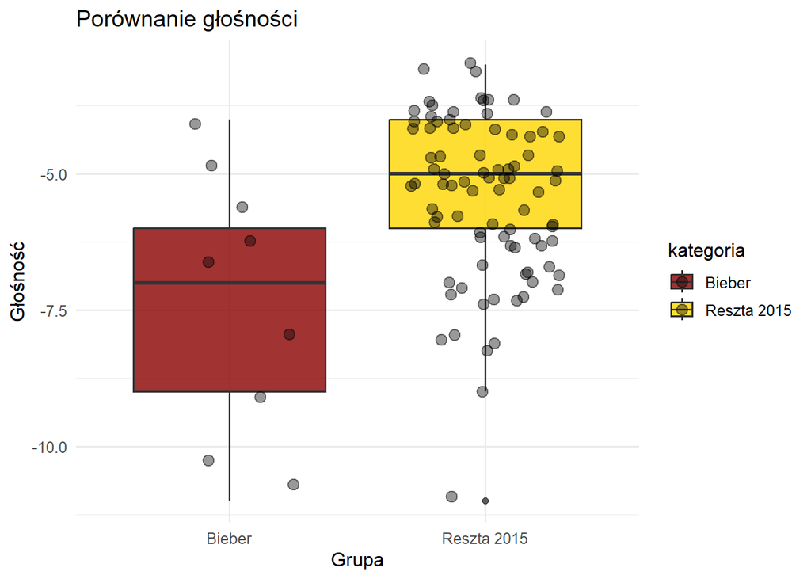

```r
dane_2015 %>%
  ggplot(aes(x = kategoria, y = dB, fill = kategoria)) +
  geom_boxplot(alpha = 0.8) +
  geom_jitter(width = 0.3, size = 3, alpha = 0.4) +
  scale_fill_manual(values = c("Bieber" = "darkred", "Reszta 2015" = "#FFD600")) +
  theme_minimal(12) +
  labs(title = "Porównanie głośności", x = "Grupa", y = "Głośność")
```

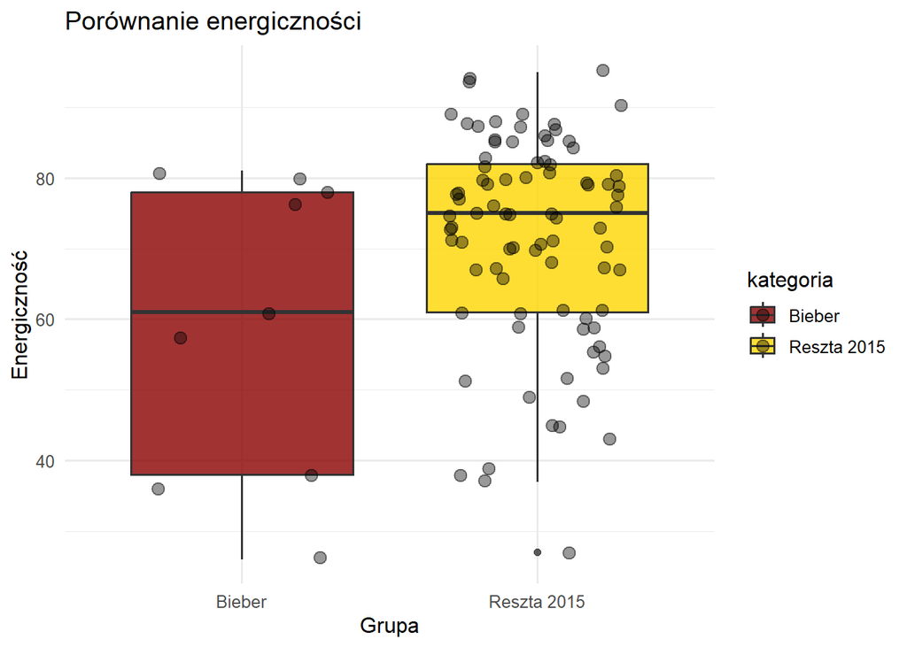

```r
dane_2015 %>%
  ggplot(aes(x = kategoria, y = nrgy, fill = kategoria)) +
  geom_boxplot(alpha = 0.8) +
  geom_jitter(width = 0.3, size = 3, alpha = 0.4) +
  scale_fill_manual(values = c("Bieber" = "darkred", "Reszta 2015" = "#FFD600")) +
  theme_minimal(12) +
  labs(title = "Porównanie energiczności",
       x = "Grupa",
       y = "Energiczność")
```

Możemy zakładać, że tak dużym powodem sukcesu artysty w roku 2015 było to, że jego muzyka jest robiona ten sposób aby każdy znalazł coś dla siebie, albo, że robiąc swoją muzykę bardziej spokojniejszą, cichszą, bardziej naturalną wpasował się w grono typowo popowe, piosenek z podobnym, łagodnym, lekkim brzmieniem. Dla pewności sprawdzę średnie dane piosenek całej dekady żeby zobaczyć czy dane z 9 lat wskażą na to, że to właśnie typ utworów jakie tworzy Bieber jest najbardziej słuchany czy może jednak był on fenomenem który sam budował trendy.

```r
dane_dekady <- spotify %>%
  mutate(kategoria = ifelse(artist == "Justin Bieber" & year == 2015, "Bieber", "Reszta Dekady"))

dane_dekady %>%
  group_by(kategoria) %>%
  summarise(
    srednie_bpm = mean(bpm),
    srednia_nrgy = mean(nrgy),
    srednia_dnce = mean(dnce),
    srednia_dB = mean(dB),
    srednie_val = mean(val),
    srednia_dur = mean(dur),
    srednia_acous = mean(acous),
    srednia_spch= mean(spch)
  )
```

```
## # A tibble: 2 × 9
##   kategoria     srednie_bpm srednia_nrgy srednia_dnce srednia_dB srednie_val
##   <chr>               <dbl>        <dbl>        <dbl>      <dbl>       <dbl>
## 1 Bieber               121.         59.2         60.9      -7.33        50.9
## 2 Reszta Dekady        119.         70.8         64.5      -5.46        52.3
## # ℹ 3 more variables: srednia_dur <dbl>, srednia_acous <dbl>,
## #   srednia_spch <dbl>
```

Dane układają się praktycznie identycznie jak dla utworów z 2015, w takim razie albo jego utwory rzeczywiście trafiają do szerszego grona słuchaczy albo artysta sam tworzy trendy.

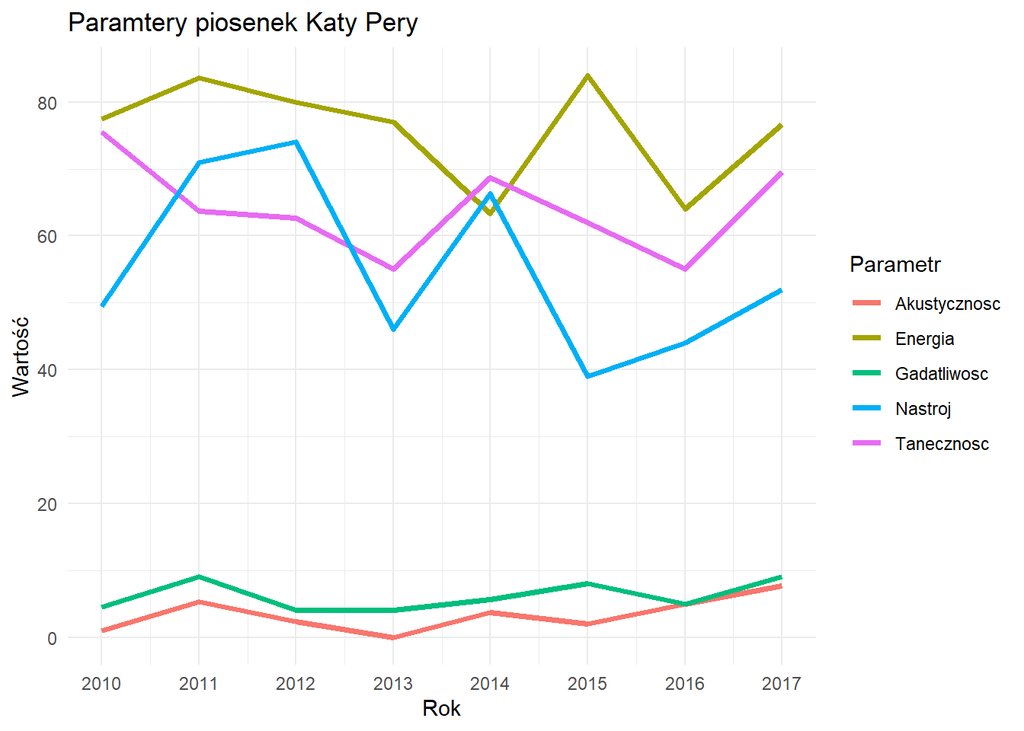

```r
Katy_Perry_dane <-spotify %>%
  filter(artist == "Katy Perry") %>%
  group_by(year) %>%
  summarise(Energia = mean(nrgy),Tanecznosc = mean(dnce), Nastroj = mean(val),Akustycznosc = mean(acous),Gadatliwosc = mean(spch))

Katy_Perry_dane%>%
  ggplot(aes(x = year)) +
  geom_line(aes(y = Energia, color = "Energia"), size = 1.3)+
  geom_line(aes(y = Tanecznosc, color = "Tanecznosc"), size = 1.3)+
  geom_line(aes(y = Nastroj, color = "Nastroj"), size = 1.3)+
  geom_line(aes(y = Akustycznosc, color = "Akustycznosc"), size = 1.3)+
  geom_line(aes(y = Gadatliwosc, color = "Gadatliwosc"), size = 1.3)+
  scale_x_continuous(breaks = 2010:2019) +
  theme_minimal(11)+
  labs(
    title = "Paramtery piosenek Katy Pery",
    x = "Rok",
    y = "Wartość",
    color = "Parametr")
```

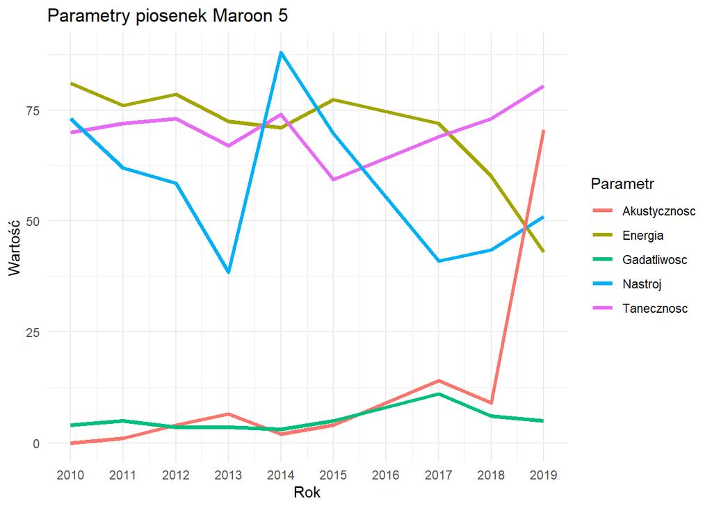

```r
Maroon5_dane <- spotify %>%
  filter(artist == "Maroon 5") %>%
  group_by(year) %>%
  summarise( Energia = mean(nrgy), Tanecznosc = mean(dnce),Nastroj = mean(val), Akustycznosc = mean(acous), Gadatliwosc = mean(spch))

Maroon5_dane %>%
  ggplot(aes(x = year)) +
  geom_line(aes(y = Energia, color = "Energia"), size = 1.3) +
  geom_line(aes(y = Tanecznosc, color = "Tanecznosc"), size = 1.3) +
  geom_line(aes(y = Nastroj, color = "Nastroj"), size = 1.3) +
  geom_line(aes(y = Akustycznosc, color = "Akustycznosc"), size = 1.3) +
  geom_line(aes(y = Gadatliwosc, color = "Gadatliwosc"), size = 1.3) +
  scale_x_continuous(breaks = 2010:2019) +
  theme_minimal(11) +
  labs(
    title = "Parametry piosenek Maroon 5",
    x = "Rok",
    y = "Wartość",
    color = "Parametr")
```

```r
spotify %>%
  filter(artist == "Katy Perry" | artist == "Maroon 5") %>%
  group_by(artist) %>%
  summarise(
    Srednie_BPM = mean(bpm),
    Srednia_Glosnosc_dB = mean(dB),
    Srednia_Dlugosc_sek = mean(dur),)
```

```
## # A tibble: 2 × 4
##   artist     Srednie_BPM Srednia_Glosnosc_dB Srednia_Dlugosc_sek
##   <chr>            <dbl>               <dbl>               <dbl>
## 1 Katy Perry        132.               -5.06                224.
## 2 Maroon 5          118.               -5.6                 218.
```

```r
spotify %>%
rename(gatunek = 3) %>%
  filter(artist == "Katy Perry" | artist == "Maroon 5") %>%
  group_by(artist, gatunek) %>%
  summarise(ile_utworow = n()) %>%
  arrange(desc(ile_utworow))
```

```
## # A tibble: 2 × 3
## # Groups:   artist [2]
##   artist     gatunek   ile_utworow
##   <chr>      <fct>           <int>
## 1 Katy Perry dance pop          17
## 2 Maroon 5   pop                15
```

Zobaczmy teraz jak na przestrzeni tych 8 lat zmieniała się głośność, poziom szczęścia, bpm oraz sytuacja z gatunkami muzycznymi, sprawdzimy czy może z u biegiem lat ludzie byli bardziej skłonni słuchać np. żywszą muzykę, a może przestawili się na bardziej emocjonalne utwory, albo w ogóle popularny stał się nowy gatunek muzyczny.

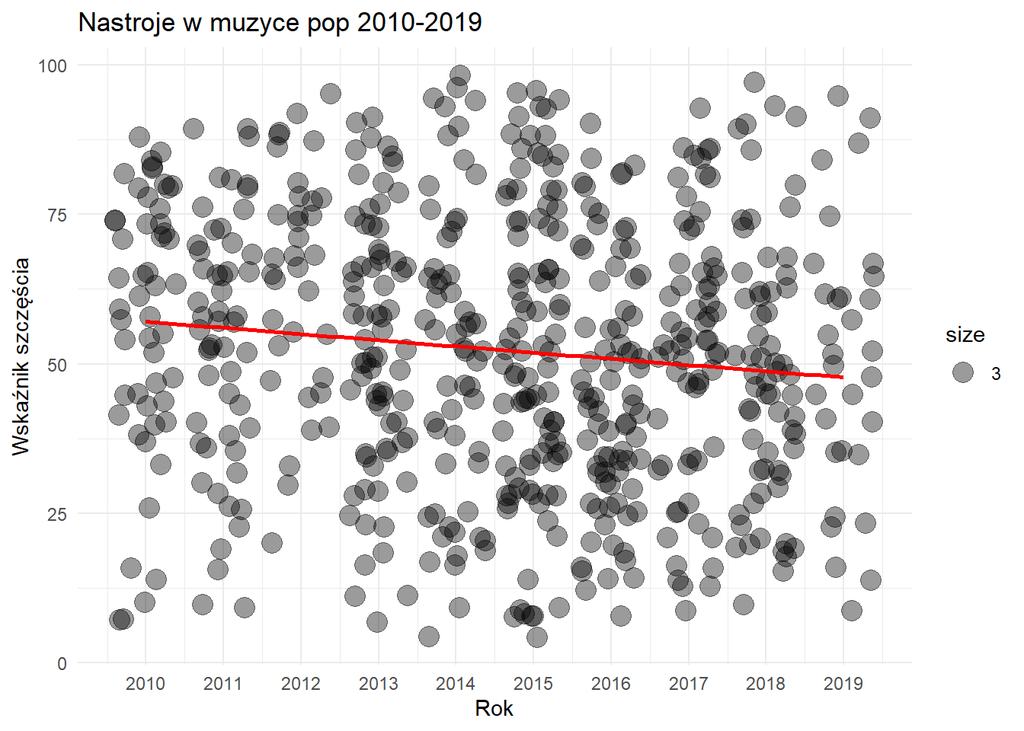

```r
spotify %>%
  ggplot(aes(x = year, y = val, size = 3)) +
  geom_jitter(alpha = 0.4, color = "grey2") +
  geom_smooth(method = "lm", color = "red", se = FALSE, size = 1) +
  scale_x_continuous(breaks = 2010:2019) +
  theme_minimal() +
  labs(
    title = "Nastroje w muzyce pop 2010-2019",
    x = "Rok",
    y = "Wskaźnik szczęścia")
```

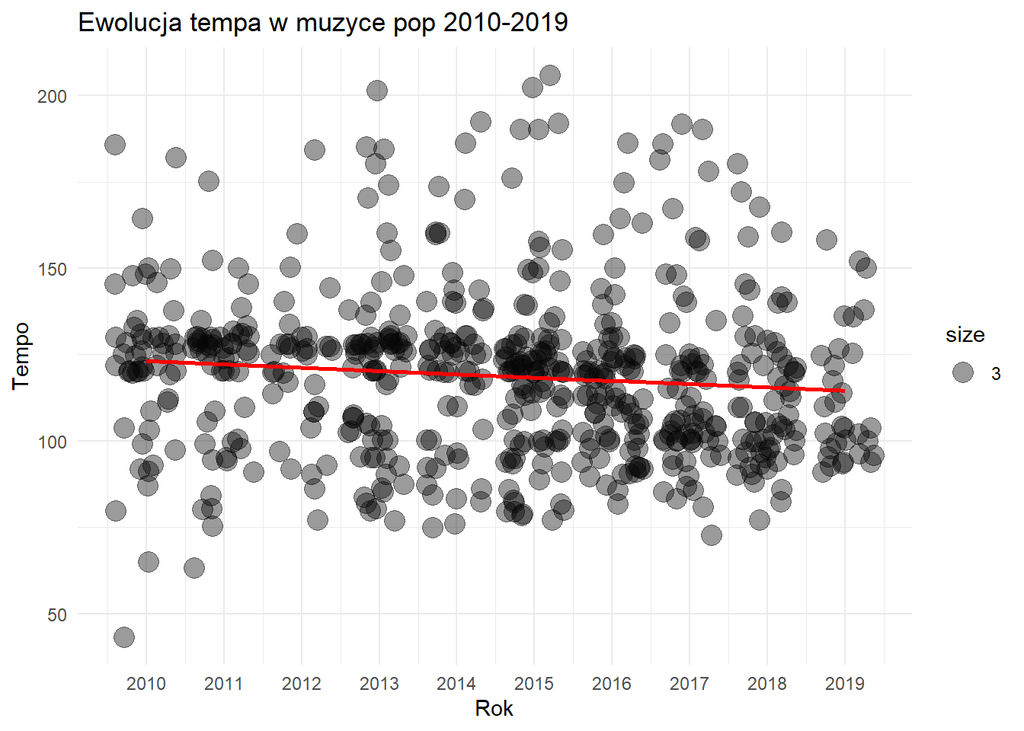

```r
spotify %>%
  ggplot(aes(x = year, y = bpm, size = 3)) +
  geom_jitter(alpha = 0.4, color = "grey2") +
  geom_smooth(method = "lm", color = "red", se = FALSE, size = 1) +
  scale_x_continuous(breaks = 2010:2019) +
  theme_minimal() +
  labs(
    title = "Ewolucja tempa w muzyce pop 2010-2019",
    x = "Rok",
    y = "Tempo")
```

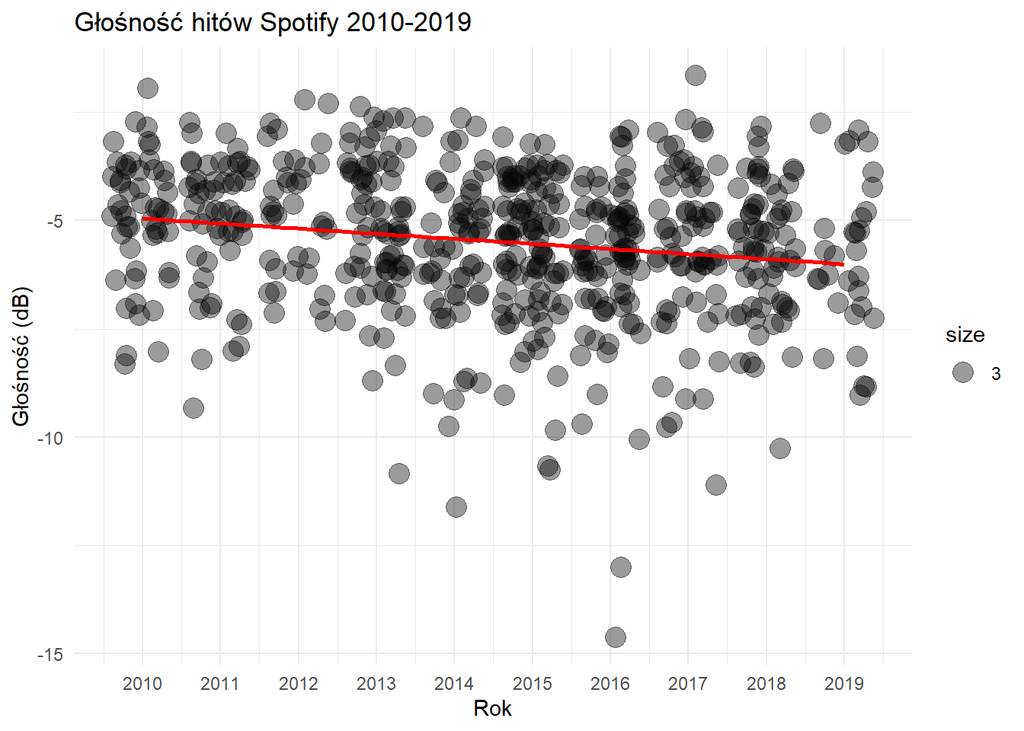

```r
spotify %>%
  ggplot(aes(x = year, y = dB, size = 3)) +
  geom_jitter(alpha = 0.4, color = "grey2") +
  geom_smooth(method = "lm", color = "red", se = FALSE, size = 1) +
  scale_x_continuous(breaks = 2010:2019) +
  theme_minimal() +
  labs(
    title = "Głośność hitów Spotify 2010-2019",
    x = "Rok",
    y = "Głośność (dB)")
```

```r
top_gatunki <- spotify %>%
  group_by(top.genre) %>%
  summarise(n = n()) %>%
  top_n(6, n) %>%
  pull(top.genre)
top_gatunki
```

```
## [1] barbadian pop boy band      canadian pop  dance pop     electropop
## [6] pop
## 50 Levels: acoustic pop alaska indie alternative r&b art pop ... tropical house
```

```r
trendy_ilosciowe <- spotify %>%
  filter(top.genre %in% c("dance pop", "pop", "canadian pop", "barbadian pop", "boy band", "electropop")) %>%
  group_by(year, top.genre) %>%
  summarise(
    ile_piosenek = n())
```

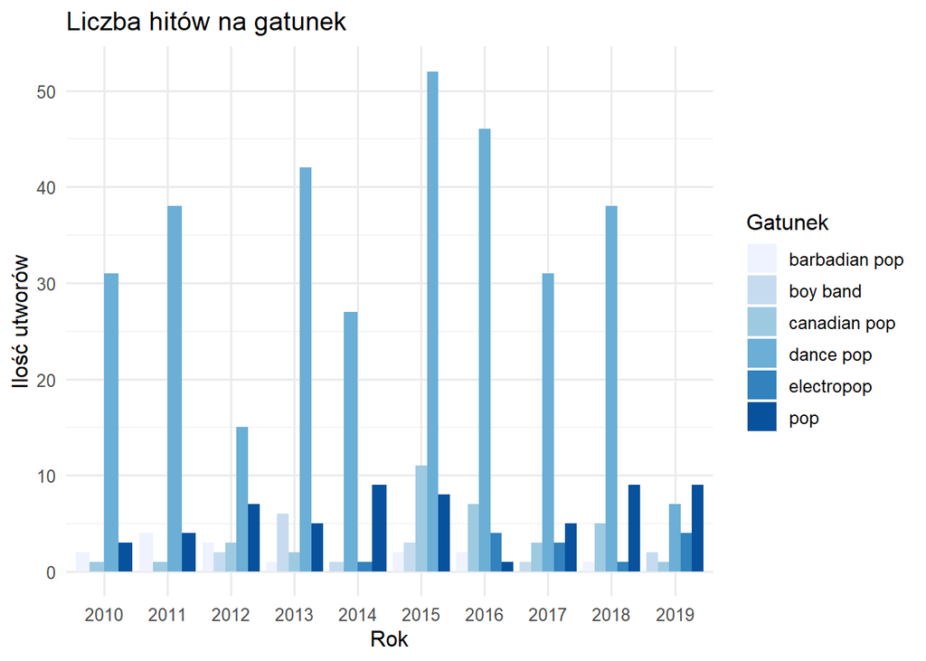

```r
trendy_ilosciowe %>%
  ggplot(aes(x = factor(year), y = ile_piosenek, fill = top.genre)) +
  geom_col(position = "dodge") +
  theme_minimal(12) +
  scale_fill_brewer() +
  labs(
    title = "Liczba hitów na gatunek",
    x = "Rok",
    y = "Ilość utworów",
    fill = "Gatunek")
```

Jeżeli chodzi o gatunki to widać, że na z całej listy dla 8 lat najczęstsze gatunki to: barbadian pop (gatunek praktycznie całkowicie zdominowany przez Rhianne), boy band, Canadian pop (który dominuje Shawn Mendes, Justin Bieber i Drake), dance pop(najczęściej słuchany gatunek), electropop i pop. Zobaczmy czemu w 2019 zainteresowanie dance pop tak gwałtownie spadło, czy wypadł on z trendu czy może zastąpił go inny nowocześniejszy gatunek.

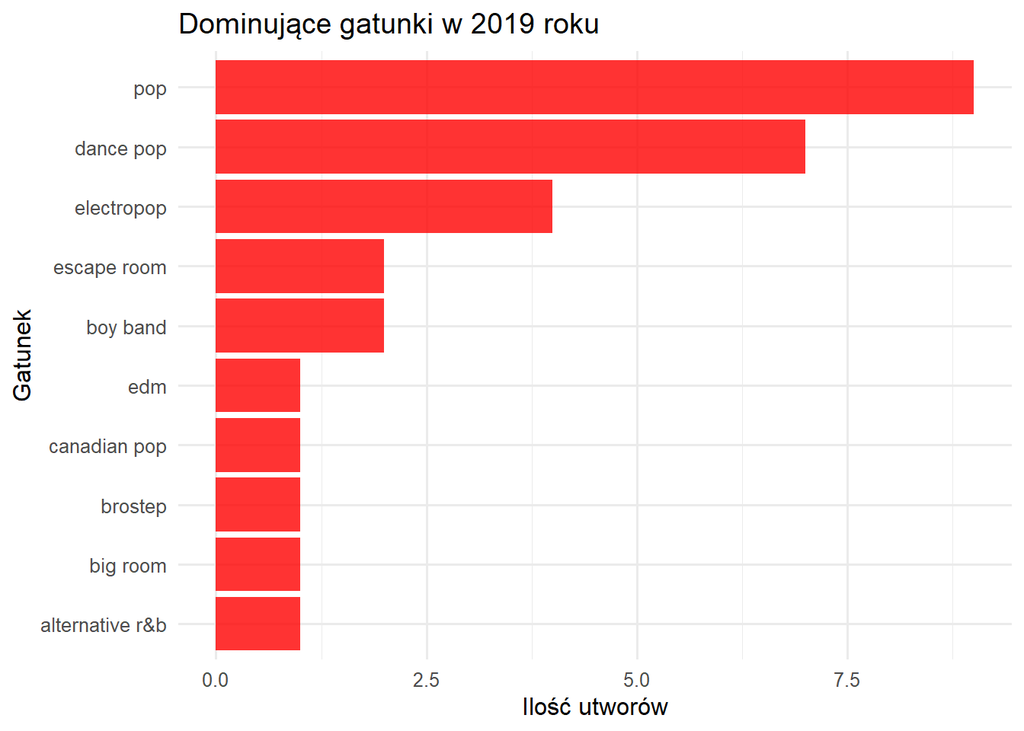

```r
top_10_2019 <- spotify %>%
  filter(year == 2019) %>%
  count(top.genre, sort = TRUE) %>%
  head(10)

top_10_2019 %>%
  ggplot(aes(x = reorder(top.genre, n), y = n)) +
  geom_col(fill = "red", alpha = 0.8) +
  coord_flip() +
  theme_minimal(base_size = 12) +
  labs(
    title = "Dominujące gatunki w 2019 roku",
    x = "Gatunek",
    y = "Ilość utworów")
```

```r
gatunki2019 <- spotify %>%
  mutate(okres = ifelse(year == 2019, "Rok 2019", "Lata 2010-2018"))

gatunki2019 %>%
  group_by(okres) %>%
  summarise(
    srednia_tanecznosc = mean(dnce),
    srednia_energia = mean(nrgy))
```

```
## # A tibble: 2 × 3
##   okres          srednia_tanecznosc srednia_energia
##   <chr>                       <dbl>           <dbl>
## 1 Lata 2010-2018               64.2            70.9
## 2 Rok 2019                     69.7            64.7
```

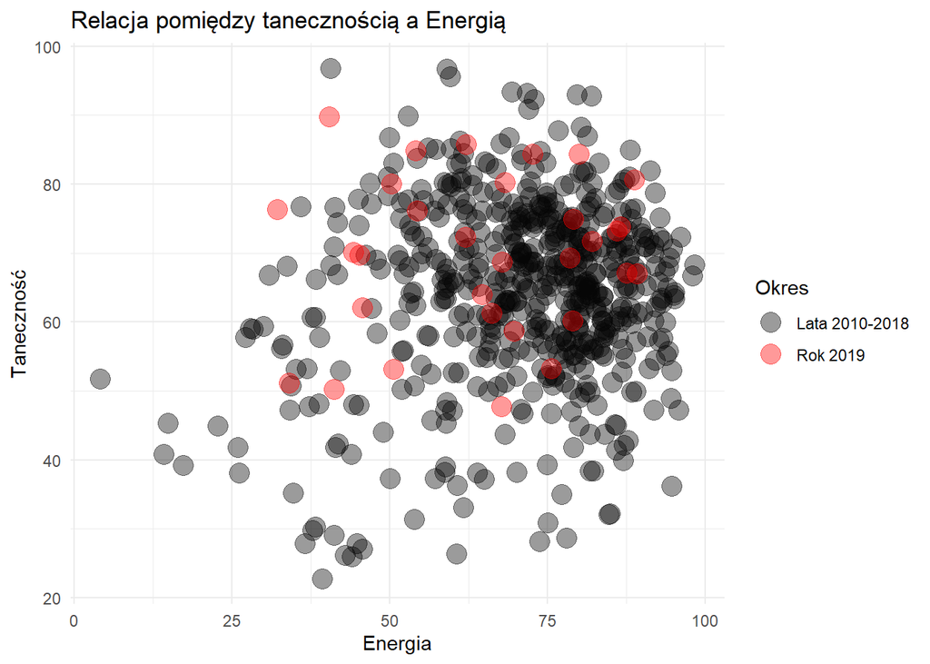

```r
gatunki2019%>%
  ggplot(aes(x = nrgy, y = dnce, color = okres)) +
  geom_jitter(alpha = 0.4, size = 5) +
  scale_color_manual(values = c("Lata 2010-2018" = "grey2", "Rok 2019" = "red")) +
  theme_minimal() +
  labs(
    title = "Relacja pomiędzy tanecznością a Energią",
    x = "Energia",
    y = "Taneczność",
    color = "Okres")
```

Sprawdźmy teraz coś innego, a konkretnie jak wygląda powiązanie pomiędzy tanecznością utworu,a wskaźnikiem szczęścia. Czy utwory którym przypisano niski wskaźnik szczęścia sugerujący ich bardziej melancholijny klimat mogą mieć duży wskaźnik szczęścia.

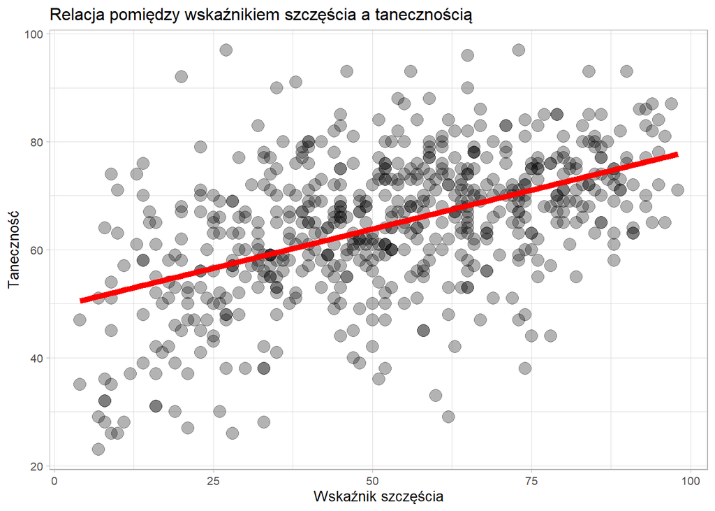

```r
spotify %>%
  ggplot(aes(x = val, y = dnce)) +
  geom_point(alpha = 0.3, size = 4) +
  geom_smooth(method = "lm", color = "red", se = FALSE, size = 2) +
  theme_light(10) +
  labs(
    title = "Relacja pomiędzy wskaźnikiem szczęścia a tanecznością",
    x = "Wskaźnik szczęścia",
    y = "Taneczność")
```

```r
top_6_lista <- spotify %>%
  count(top.genre, sort = TRUE) %>%
  top_n(6, n) %>%
  pull(top.genre)
```

Z wykresu możemy odczytać parę rzeczy, po pierwsze istnieje dodatnia korelacja pomiędzy szczęściem, a tanecznością, ponieważ linia trendu skierowana jest ku górze, po drugie, pomimo melancholijnego nastroju piosenki nadal mogą mieć wysoką taneczność widać to z lewej strony wykresu gdzie dla VAL < 25 pojawiają się piosenki z tanecznością ponad 50. Ostatnie co można zauważyć, że jednak piosenki z najmniejszym wskaźnikiem szczęścia posiadają też najmniejszą taneczność, natomiast piosenki o dość wysokim praktycznie zawsze są mocno taneczne.

Teraz zobaczymy czy z biegiem lat piosenki stają się coraz krótsze tak jak wszystk ow social mediach czy może jest to źródło odporne na obecne zmiany.

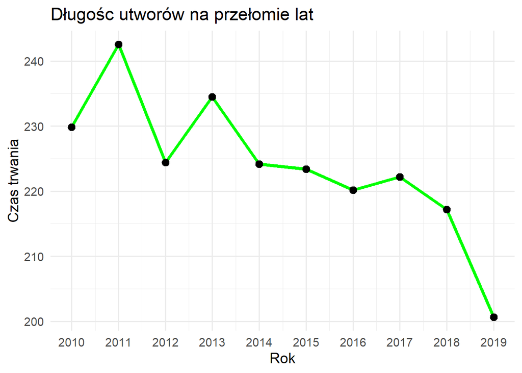

```r
spotify %>%
  group_by(year) %>%
  summarise(srednia_dlugosc = mean(dur)) %>%
  ggplot(aes(x = year, y = srednia_dlugosc)) +
  geom_line(size = 1.5, color = "green") +
  geom_point(size = 3) +
  scale_x_continuous(breaks = 2010:2019) +
  theme_minimal(14) +
  labs(title = "Długośc utworów na przełomie lat", x = "Rok", y = "Czas trwania")
```

Sprawdzimy czy z upływem lat obecna muzyka staje się coraz to smutniejsza pomimo tego, że wiemy, że poziom taneczności wcale nie spadł w ciągu 9 lat.

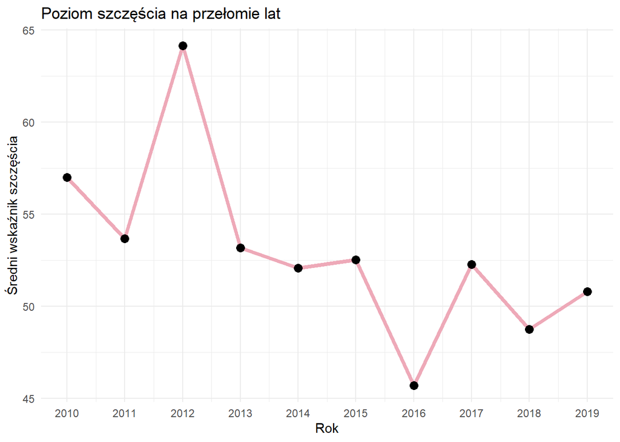

```r
spotify %>%
  group_by(year) %>%
  summarise(srednia_val = mean(val)) %>%
  ggplot(aes(x = year, y = srednia_val)) +
  geom_line(size = 1.5, color = "pink2") +
  geom_point(size = 3) +
  scale_x_continuous(breaks = 2010:2019) +
  theme_minimal() +
  labs(
    title = "Poziom szczęścia na przełomie lat",
    x = "Rok",
    y = "Średni wskaźnik szczęścia"
  )
```

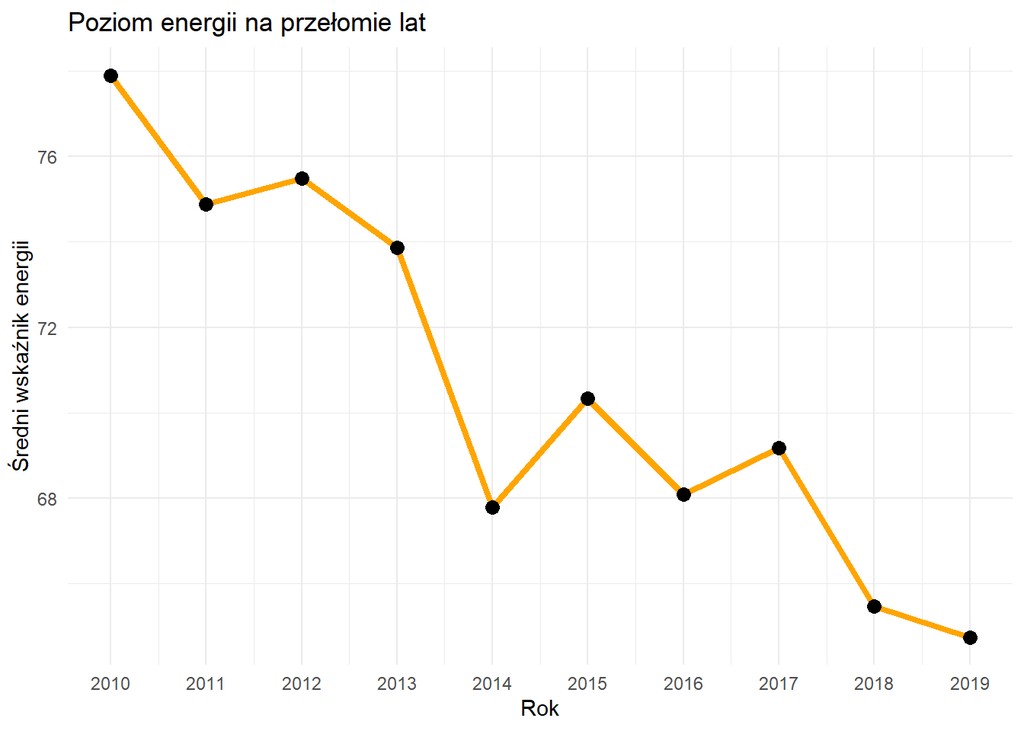

```r
spotify %>%
  group_by(year) %>%
  summarise(srednia_nrgy = mean(nrgy)) %>%
  ggplot(aes(x = year, y = srednia_nrgy)) +
  geom_line(size = 1.5, color = "orange") +
  geom_point(size = 3) +
  scale_x_continuous(breaks = 2010:2019) +
  theme_minimal() +
  labs(
    title = "Poziom energii na przełomie lat",
    x = "Rok",
    y = "Średni wskaźnik energii"
  )
```

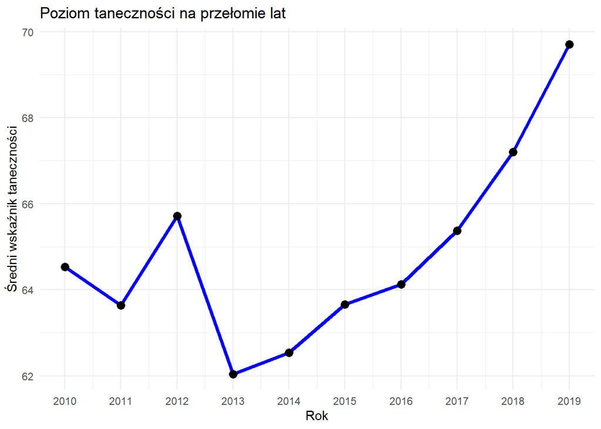

```r
spotify %>%
  group_by(year) %>%
  summarise(srednia_dnce = mean(dnce)) %>%
  ggplot(aes(x = year, y = srednia_dnce)) +
  geom_line(size = 1.5, color = "blue") +
  geom_point(size = 3) +
  scale_x_continuous(breaks = 2010:2019) +
  theme_minimal() +
  labs(
    title = "Poziom taneczności na przełomie lat",
    x = "Rok",
    y = "Średni wskaźnik taneczności"
  )
```

Z wykresu ewidentnie widać jak z biegiem lat utwory zaczęła być coraz to mnie szczęśliwe wraz ze spadkiem w 2016 tak samo energia utworów z roku na rok zaczęła spadać, nie są to jednak wartości na tyle znaczące żeby stwierdzić, że ludzie zaczęli słuchać muzyki bardziej melancholijnej